# Linear Regression

# Data Description

Wages dataset is a simulated dataset based on a real dataset published in Data Analysis using Regression and Multilevel/Hierarchical Models by Andrew Gelman and Jennifer Hill

Data consists of characteristics of a set of employees and their annual earning. Variables included are:

- earn: Annual earning in dollars
- height: Height in inches
- gender: Gender (male, female)
- race: african-american, asian, hispanic, white
- ed: Years of education
- age: Age in years

# Read Data

Set your working directory to the location where `wages.csv` is saved by adapting the code below.

```r
setwd('c:/my_classes/best_course_ever/') # on Windows
setwd('/my_classes/best_course_ever/') # on Mac
```

Read in `wages.csv`

```r
wages = read.csv('wages.csv',stringsAsFactors = T)
```

# Clean data

## Examine distribution of Earn

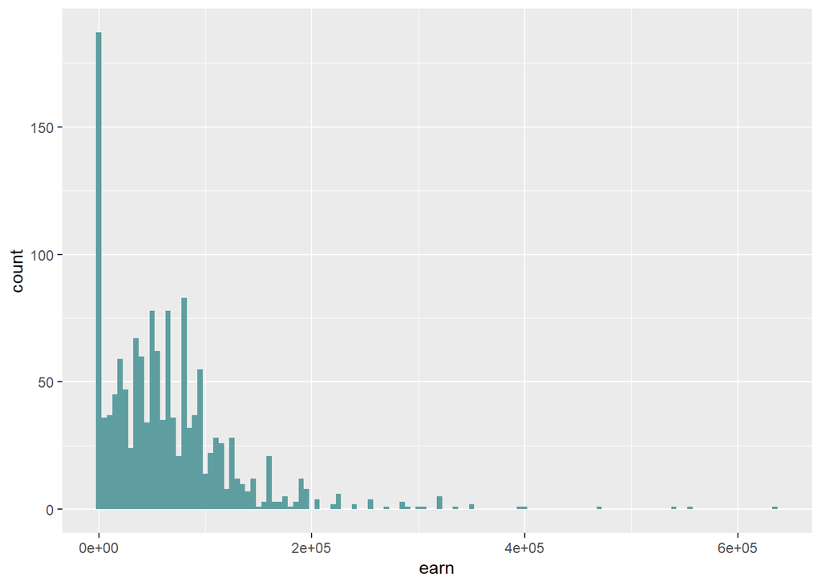

```r
library(ggplot2)
ggplot(data=wages,aes(x=earn))+
  geom_histogram(binwidth=5000,fill='cadetblue')
```

## Remove negative earn

```r
sum(wages$earn<0)
```

```
## [1] 11
```

```r
wages = wages[wages$earn>=0,]
```

# Data Partition

Evaluating a model using data to estimate it risks overfitting the model to the data used to build it. For this reason, it is best to evaluate the model using a different dataset. Since getting a fresh dataset for evaluating a model may be costly, time consuming and in some cases impossible, it is common to split the data into a train and test sample, estimating the model using the train and evaluating it using the test.

Let us start by splitting the data into a train and test sample such that 70% of the data is in the train sample. Use createDataPartition from the caret package with groups = 20. Set seed to 1031 and be sure to do this just before passing createDataPartition()

```r
library(caret)
set.seed(1031)
split = createDataPartition(y=wages$earn,p = 0.7,list = F,groups = 20)
train = wages[split,]
test = wages[-split,]
```

# Explore Data

```r
str(train)
```

```
## 'data.frame':    968 obs. of  6 variables:
##  $ earn  : int  159142 192794 97422 160956 164178 20658 2004 95196 40128 1986 ...
##  $ height: num  73.9 66.2 63.8 63.2 63.1 ...
##  $ gender: Factor w/ 2 levels "female","male": 2 1 1 1 1 2 1 2 1 1 ...
##  $ race  : Factor w/ 4 levels "african-american",..: 4 4 4 2 4 4 4 4 4 4 ...
##  $ ed    : int  16 16 16 16 17 16 14 11 12 12 ...
##  $ age   : int  49 62 33 95 43 69 54 38 55 31 ...
```

```r
head(train)
```

|  | earn | height | gender | race | ed | age |
| --- | --- | --- | --- | --- | --- | --- |
| 1 | 159142 | 73.89 | male | white | 16 | 49 |
| 2 | 192794 | 66.23 | female | white | 16 | 62 |
| 3 | 97422 | 63.77 | female | white | 16 | 33 |
| 4 | 160956 | 63.22 | female | asian | 16 | 95 |
| 5 | 164178 | 63.08 | female | white | 17 | 43 |
| 11 | 20658 | 70.22 | male | white | 16 | 69 |

```r
library(skimr)
skim(train)
```

Data summary

| Name | train |
| --- | --- |
| Number of rows | 968 |
| Number of columns | 6 |
| _______________________ |  |
| Column type frequency: |  |
| factor | 2 |
| numeric | 4 |
| ________________________ |  |
| Group variables | None |

**Variable type: factor**

| skim_variable | n_missing | complete_rate | ordered | n_unique | top_counts |
| --- | --- | --- | --- | --- | --- |
| gender | 0 | 1 | FALSE | 2 | fem: 608, mal: 360 |
| race | 0 | 1 | FALSE | 4 | whi: 809, afr: 89, his: 53, asi: 17 |

**Variable type: numeric**

| skim_variable | n_missing | complete_rate | mean | sd | p0 | p25 | p50 | p75 | p100 | hist |
| --- | --- | --- | --- | --- | --- | --- | --- | --- | --- | --- |
| earn | 0 | 1 | 64813.67 | 59413.93 | 52.00 | 21128.00 | 54108.00 | 89054.00 | 556428.00 | ▇▁▁▁▁ |
| height | 0 | 1 | 66.53 | 3.72 | 57.34 | 63.76 | 66.03 | 69.09 | 77.21 | ▁▇▇▅▁ |
| ed | 0 | 1 | 13.39 | 2.50 | 3.00 | 12.00 | 13.00 | 16.00 | 18.00 | ▁▁▇▅▅ |
| age | 0 | 1 | 45.48 | 15.73 | 22.00 | 33.00 | 43.00 | 56.00 | 95.00 | ▇▇▃▂▁ |

## Examine outliers

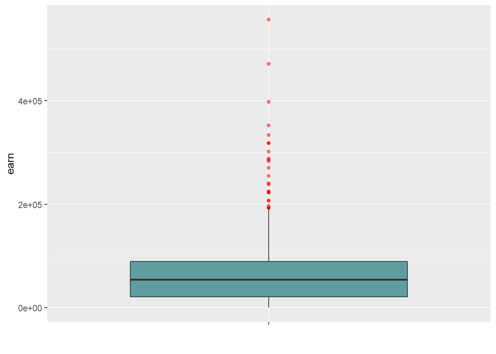

```r
ggplot(data=train,aes(x='',y=earn))+
  geom_boxplot(outlier.color='red',outlier.alpha=0.5, fill='cadetblue')+
  geom_text(aes(x='',y=median(train$earn),label=median(train$earn)),size=3,hjust=11)+
  xlab(label = '')
```

# Model 1, Simple Regression: earn = f(age)

## Visualize

A scatterplot is the best way to visualize a relationship between two numeric variables. Is there a discernible trend?

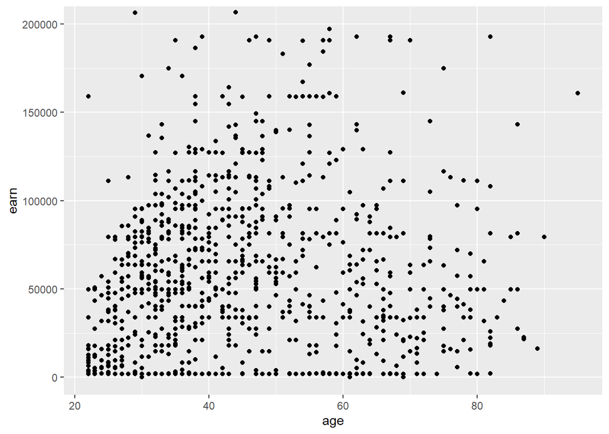

```r
library(ggplot2)
ggplot(data=train,aes(x=age,y=earn))+
  geom_point()+
  coord_cartesian(ylim=c(0,200000))
```

## Correlation

Is there a linear relationship?

```r
cor(train$age,train$earn)
```

```
## [1] 0.07570427
```

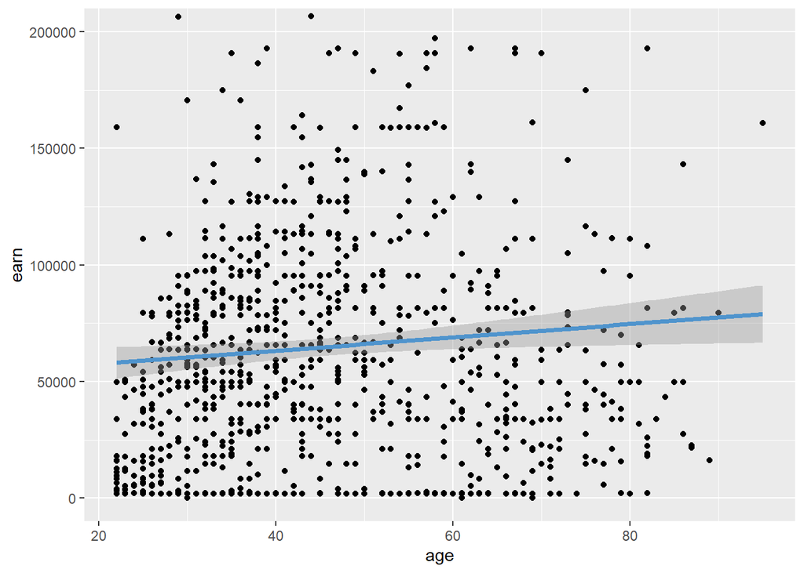

```r
ggplot(data=train,aes(x=age,y=earn))+
  geom_point()+
  geom_smooth(method='lm',size=1.3,color='steelblue3')+
  coord_cartesian(ylim=c(0,200000))
```

## Estimate

```r
model1 = lm(earn~age,data=train)
paste('earn','=',round(coef(model1)[1],0),'+',round(coef(model1)[2],0),'age')
```

```
## [1] "earn = 51806 + 286 age"
```

## Predict

```r
anova(model1)
```

|  | Df | Sum Sq | Mean Sq | F value | Pr(>F) |
| --- | --- | --- | --- | --- | --- |
| age | 1 | 1.956337e+10 | 19563374442 | 5.56819 | 0.01848774 |
| Residuals | 966 | 3.393961e+12 | 3513417041 | NA | NA |

```r
summary(model1)
```

```
##
## Call:
## lm(formula = earn ~ age, data = train)
##
## Residuals:
##    Min     1Q Median     3Q    Max
## -73231 -42620  -9617  25063 489751
##
## Coefficients:
##             Estimate Std. Error t value Pr(>|t|)
## (Intercept)  51805.6     5832.5   8.882   <2e-16 ***
## age            286.0      121.2   2.360   0.0185 *
## ---
## Signif. codes:  0 '***' 0.001 '**' 0.01 '*' 0.05 '.' 0.1 ' ' 1
##
## Residual standard error: 59270 on 966 degrees of freedom
## Multiple R-squared:  0.005731,   Adjusted R-squared:  0.004702
## F-statistic: 5.568 on 1 and 966 DF,  p-value: 0.01849
```

```r
pred = predict(model1)
data.frame(earn = train$earn[100:109], prediction = pred[100:109])
```

|  | earn | prediction |
| --- | --- | --- |
| 143 | 75146 | 64961.40 |
| 144 | 2010 | 64103.41 |
| 146 | 47758 | 61815.44 |
| 147 | 14690 | 73255.28 |
| 149 | 97418 | 62101.44 |
| 150 | 89422 | 61529.45 |
| 152 | 59222 | 68965.34 |
| 153 | 136514 | 65533.39 |
| 154 | 103778 | 65533.39 |
| 155 | 1990 | 67535.36 |

```r
sse = sum((pred - train$earn)^2)
sst = sum((mean(train$earn)-train$earn)^2)
model1_r2 = 1 - sse/sst; model1_r2
```

```
## [1] 0.005731137
```

```r
sse1 = sum((pred-train$earn)^2); sse1
```

```
## [1] 3.393961e+12
```

```r
rmse1 = sqrt(mean((pred-train$earn)^2)); rmse1
```

```
## [1] 59212.82
```

## Inference

Does age influence earn?  
What would be the wage of a 35 year old person? One can answer this question by manually substituting 35 in the regression equation.

```r
model1$coef[1]+ model1$coef[2]*35
```

```
## (Intercept)
##    61815.44
```

However, a better alternative is to use the `predict` function

```r
predict(model1,newdata=data.frame(age=35))
```

```
##        1
## 61815.44
```

How much more would a 45 year old than a 35 year old? Generally speaking, what would a 10 year increase in age do to one’s wage

# Model 2, Simple Regression: earn = f(height)

## Visualize

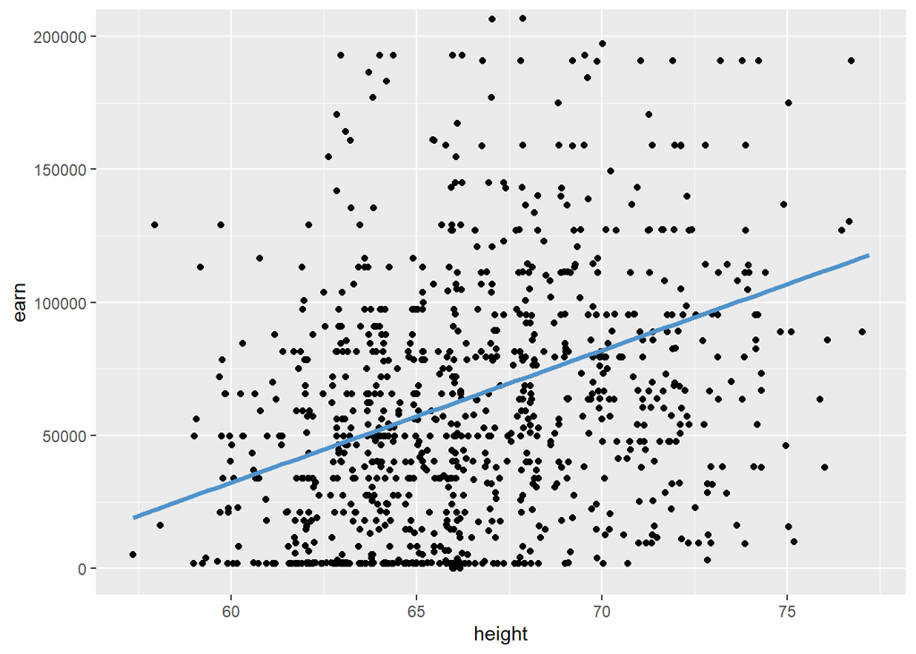

```r
ggplot(aes(x=height,y=earn),data=train)+
  geom_point()+
  geom_smooth(method="lm",size=1.3,color='steelblue3',se=FALSE)+
  coord_cartesian(ylim = c(0,200000))
```

## Estimate

```r
model2 = lm(earn~height,data=train)
paste('earn','=',round(coef(model2)[1],0),'+',round(coef(model2)[2],0),'height')
```

```
## [1] "earn = -265590 + 4966 height"
```

## Predict

```r
summary(model2)
```

```
##
## Call:
## lm(formula = earn ~ height, data = train)
##
## Residuals:
##    Min     1Q Median     3Q    Max
## -97671 -38690  -9155  23473 469181
##
## Coefficients:
##              Estimate Std. Error t value Pr(>|t|)
## (Intercept) -265589.6    32522.7  -8.166 9.88e-16 ***
## height         4966.0      488.1  10.175  < 2e-16 ***
## ---
## Signif. codes:  0 '***' 0.001 '**' 0.01 '*' 0.05 '.' 0.1 ' ' 1
##
## Residual standard error: 56490 on 966 degrees of freedom
## Multiple R-squared:  0.0968, Adjusted R-squared:  0.09587
## F-statistic: 103.5 on 1 and 966 DF,  p-value: < 2.2e-16
```

```r
pred = predict(model2)
data.frame(earn = train$earn[100:109], prediction = pred[100:109])
```

|  | earn | prediction |
| --- | --- | --- |
| 143 | 75146 | 82777.74 |
| 144 | 2010 | 42801.16 |
| 146 | 47758 | 87197.51 |
| 147 | 14690 | 81337.59 |
| 149 | 97418 | 53031.19 |
| 150 | 89422 | 67581.67 |
| 152 | 59222 | 41112.71 |
| 153 | 136514 | 71852.46 |
| 154 | 103778 | 44787.57 |
| 155 | 1990 | 63112.24 |

```r
sse2 = sum((pred - train$earn)^2)
sst2 = sum((mean(train$earn)-train$earn)^2)
model2_r2 = 1 - sse2/sst2; model2_r2
```

```
## [1] 0.09680031
```

```r
rmse2 = sqrt(mean((pred-train$earn)^2)); rmse2
```

```
## [1] 56435.93
```

## Inference

Does height influence earn?

```r
summary(model2)
```

```
##
## Call:
## lm(formula = earn ~ height, data = train)
##
## Residuals:
##    Min     1Q Median     3Q    Max
## -97671 -38690  -9155  23473 469181
##
## Coefficients:
##              Estimate Std. Error t value Pr(>|t|)
## (Intercept) -265589.6    32522.7  -8.166 9.88e-16 ***
## height         4966.0      488.1  10.175  < 2e-16 ***
## ---
## Signif. codes:  0 '***' 0.001 '**' 0.01 '*' 0.05 '.' 0.1 ' ' 1
##
## Residual standard error: 56490 on 966 degrees of freedom
## Multiple R-squared:  0.0968, Adjusted R-squared:  0.09587
## F-statistic: 103.5 on 1 and 966 DF,  p-value: < 2.2e-16
```

What impact will a two inch increase in height have on your wage?

```r
2 * coef(model2)[2]
```

```
##   height
## 9932.069
```

## How much will a six foot person earn (all else being equal)?

```r
predict(model2,newdata=data.frame(height=72))
```

```
##       1
## 91964.9
```

# Model 3, Simple Regression (Categorical Predictor): earn = f(gender)

## Visualize

Simple Regression with a Categorical Variable. When exploring the relationship with a categorical variable, a scatterplot is not an option. Bar chart makes more sense.

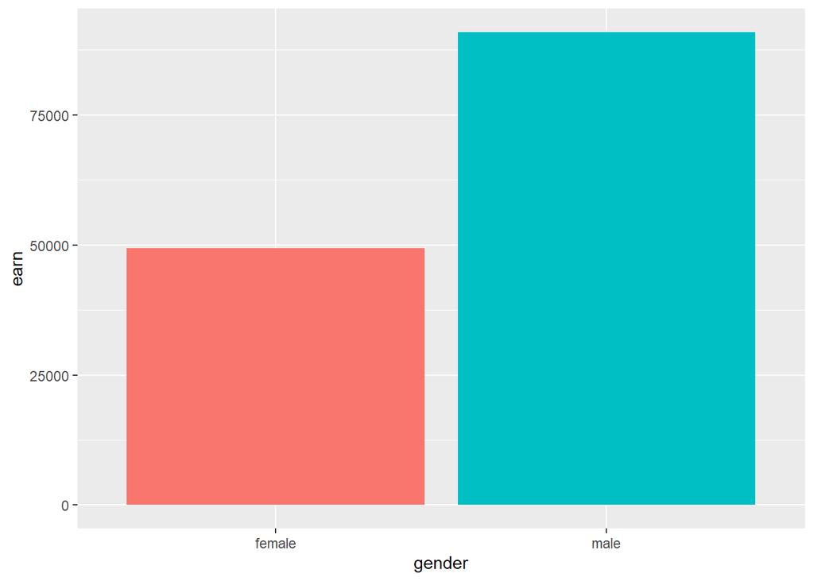

```r
ggplot(data=train,aes(x=gender,y=earn,fill=gender))+
  geom_bar(stat='summary',fun='mean',position='dodge')+
  guides(fill=F)
```

Adding error bars to gain greater insight.

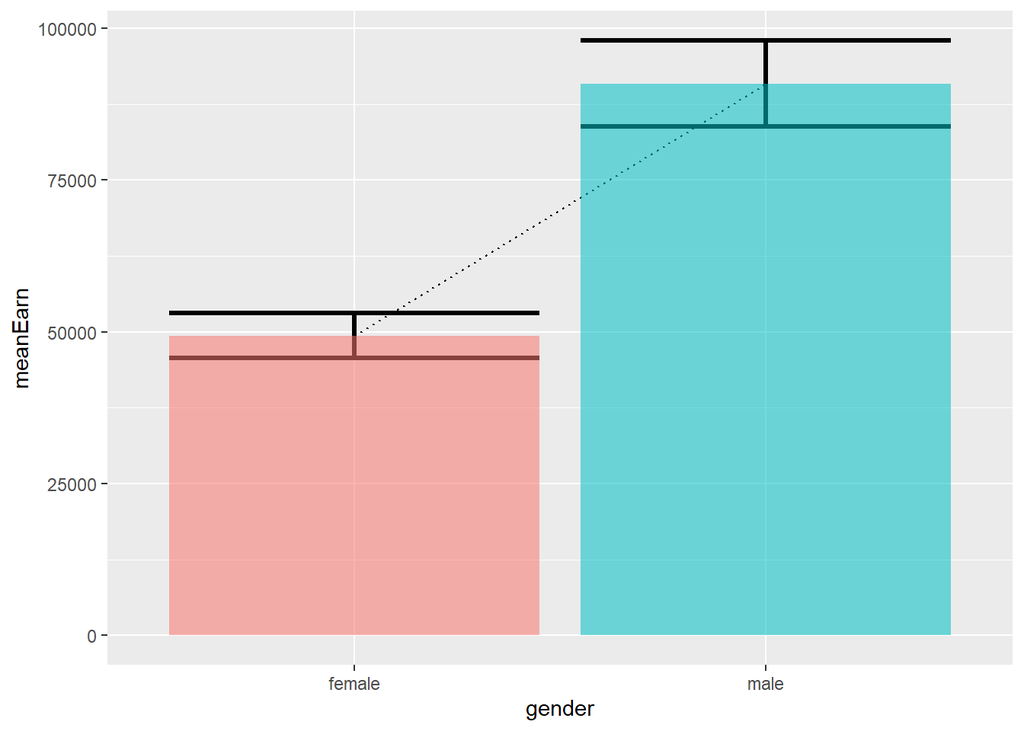

```r
library(dplyr)
train%>%
  group_by(gender)%>%
  summarise(meanEarn=mean(earn),earnLow=mean(earn)-1.96*sd(earn)/sqrt(n()),earnHigh=mean(earn)+1.96*sd(earn)/sqrt(n()))%>%
  ungroup()%>%
  ggplot(aes(x=gender,y=meanEarn))+
  geom_errorbar(aes(ymin=earnLow,ymax=earnHigh),size=1.1)+
  geom_line(aes(x=gender,y=meanEarn,group=1),linetype=3)+
  geom_bar(data=train,aes(x=gender,y=earn,alpha=0.2,fill=gender),stat='summary',fun='mean',position='dodge')+
  guides(fill=F,alpha=F)
```

## Estimate

Now, construct and interpret a simple regression using gender as IV. Note gender is a categorical variable

```r
model3 = lm(earn~gender,data=train)
class(train$gender) # factor
```

```
## [1] "factor"
```

```r
levels(train$gender)
```

```
## [1] "female" "male"
```

```r
table(train$gender) # for an unordered factor, levels are in alphabetical order
```

```
##
## female   male
##    608    360
```

## Predict

```r
summary(model3)
```

```
##
## Call:
## lm(formula = earn ~ gender, data = train)
##
## Residuals:
##    Min     1Q Median     3Q    Max
## -90850 -40768  -9237  22619 465526
##
## Coefficients:
##             Estimate Std. Error t value Pr(>|t|)
## (Intercept)    49367       2269   21.76   <2e-16 ***
## gendermale     41536       3720   11.16   <2e-16 ***
## ---
## Signif. codes:  0 '***' 0.001 '**' 0.01 '*' 0.05 '.' 0.1 ' ' 1
##
## Residual standard error: 55940 on 966 degrees of freedom
## Multiple R-squared:  0.1143, Adjusted R-squared:  0.1134
## F-statistic: 124.6 on 1 and 966 DF,  p-value: < 2.2e-16
```

```r
pred = predict(model3)
data.frame(earn = train$earn[100:109], prediction = pred[100:109])
```

|  | earn | prediction |
| --- | --- | --- |
| 143 | 75146 | 49366.53 |
| 144 | 2010 | 49366.53 |
| 146 | 47758 | 90902.18 |
| 147 | 14690 | 49366.53 |
| 149 | 97418 | 49366.53 |
| 150 | 89422 | 49366.53 |
| 152 | 59222 | 49366.53 |
| 153 | 136514 | 90902.18 |
| 154 | 103778 | 49366.53 |
| 155 | 1990 | 49366.53 |

```r
sse3 = sum((pred - train$earn)^2)
sst3 = sum((mean(train$earn)-train$earn)^2)
model3_r2 = 1 - sse3/sst3; model3_r2
```

```
## [1] 0.1142799
```

```r
rmse3 = sqrt(mean((pred-train$earn)^2)); rmse3
```

```
## [1] 55887.16
```

## Inference

Do females earn more than males? What is the difference?

View results using anova table

```r
anova(model3)
```

|  | Df | Sum Sq | Mean Sq | F value | Pr(>F) |
| --- | --- | --- | --- | --- | --- |
| gender | 1 | 3.900973e+11 | 390097252844 | 124.638 | 2.637244e-27 |
| Residuals | 966 | 3.023427e+12 | 3129841598 | NA | NA |

Visualizing data can show things that the indices may not reveal. Dig deeper by plotting a density plot. What do you find?

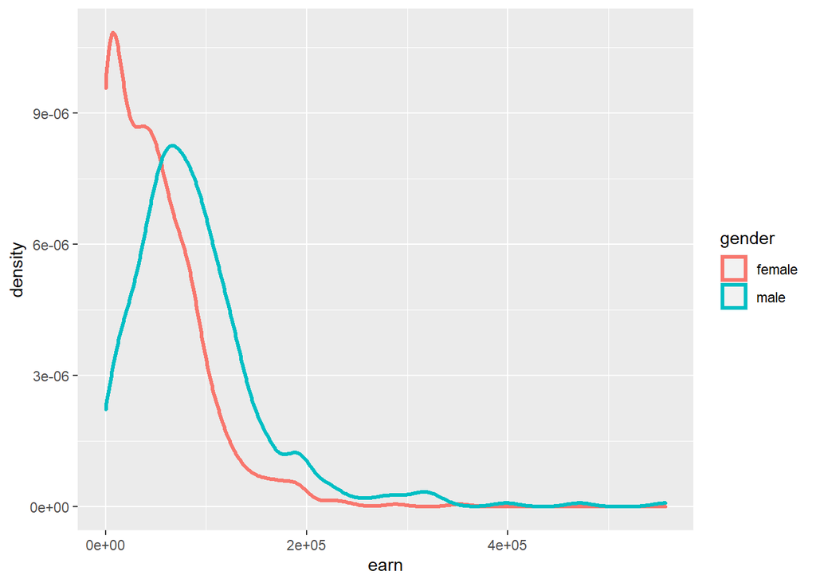

```r
ggplot(data=train,aes(x=earn,color=gender))+
  geom_density(size=1.1)
```

# Model 4, Simple Regression (categorical predictor): earn = f(race)

## Visualize Relationship

Examine relationship between race and earn. Since race (like gender) is also a categorical variable, we will use a bar chart.

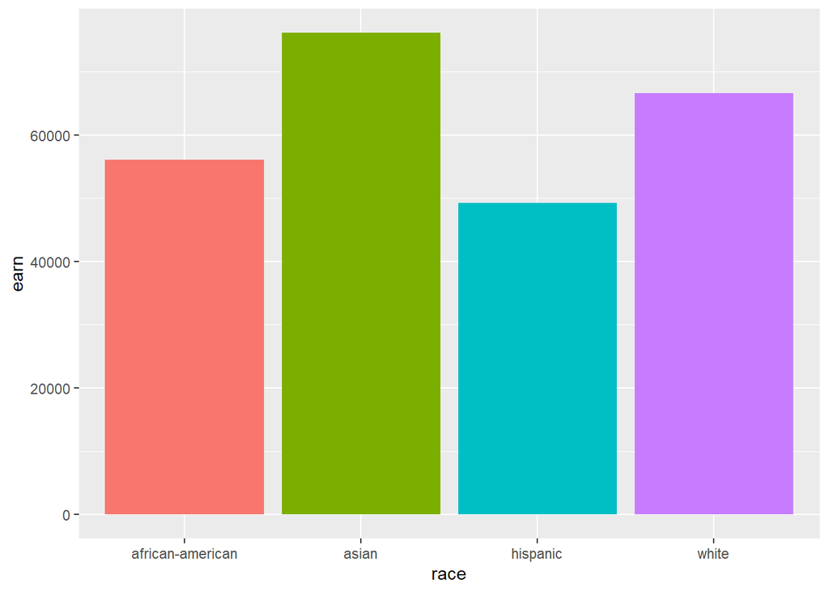

```r
ggplot(data=train,aes(x=race,y=earn,fill=race))+
  geom_bar(stat='summary',fun='mean',position='dodge')+
  guides(fill=F)
```

```r
class(train$race)
```

```
## [1] "factor"
```

```r
levels(train$race)
```

```
## [1] "african-american" "asian"            "hispanic"         "white"
```

```r
table(train$race)
```

```
##
## african-american            asian         hispanic            white
##               89               17               53              809
```

## Estimate Model

```r
model4 = lm(earn~race,train)
```

## Predict

```r
summary(model4)
```

```
##
## Call:
## lm(formula = earn ~ race, data = train)
##
## Residuals:
##    Min     1Q Median     3Q    Max
## -74127 -42813 -10480  24489 489869
##
## Coefficients:
##              Estimate Std. Error t value Pr(>|t|)
## (Intercept)     56079       6285   8.922   <2e-16 ***
## raceasian       20040      15694   1.277    0.202
## racehispanic    -6865      10288  -0.667    0.505
## racewhite       10480       6622   1.583    0.114
## ---
## Signif. codes:  0 '***' 0.001 '**' 0.01 '*' 0.05 '.' 0.1 ' ' 1
##
## Residual standard error: 59290 on 964 degrees of freedom
## Multiple R-squared:  0.007126,   Adjusted R-squared:  0.004037
## F-statistic: 2.306 on 3 and 964 DF,  p-value: 0.07522
```

```r
pred = predict(model4)
data.frame(earn = train$earn[100:109], prediction = pred[100:109])
```

|  | earn | prediction |
| --- | --- | --- |
| 143 | 75146 | 66559.09 |
| 144 | 2010 | 66559.09 |
| 146 | 47758 | 66559.09 |
| 147 | 14690 | 66559.09 |
| 149 | 97418 | 66559.09 |
| 150 | 89422 | 66559.09 |
| 152 | 59222 | 49213.47 |
| 153 | 136514 | 56078.70 |
| 154 | 103778 | 56078.70 |
| 155 | 1990 | 56078.70 |

```r
sse4 = sum((pred - train$earn)^2)
sst4 = sum((mean(train$earn)-train$earn)^2)
model4_r2 = 1 - sse4/sst4; model4_r2
```

```
## [1] 0.007126448
```

```r
rmse4 = sqrt(mean((pred-train$earn)^2)); rmse4
```

```
## [1] 59171.26
```

## Inference

Does race influence earn?  
On average, how much do those with race “african-american” earn  
If race influenced earn, who would you say earns more, whites or asian and what is the difference?

# Model 5, Multiple Regression: earn = f(height, gender)

## Estimate

```r
model5 = lm(earn~height+gender,data=train)
```

## Predict

```r
summary(model5)
```

```
##
## Call:
## lm(formula = earn ~ height + gender, data = train)
##
## Residuals:
##    Min     1Q Median     3Q    Max
## -94594 -38205  -9531  23462 462840
##
## Coefficients:
##              Estimate Std. Error t value Pr(>|t|)
## (Intercept) -101841.9    43318.5  -2.351 0.018923 *
## height         2343.0      670.3   3.495 0.000495 ***
## gendermale    28961.2     5159.9   5.613  2.6e-08 ***
## ---
## Signif. codes:  0 '***' 0.001 '**' 0.01 '*' 0.05 '.' 0.1 ' ' 1
##
## Residual standard error: 55620 on 965 degrees of freedom
## Multiple R-squared:  0.1254, Adjusted R-squared:  0.1235
## F-statistic: 69.15 on 2 and 965 DF,  p-value: < 2.2e-16
```

```r
pred = predict(model5)

sse5 = sum((pred - train$earn)^2)
sst5 = sum((mean(train$earn)-train$earn)^2)
model5_r2 = 1 - sse5/sst5; model5_r2
```

```
## [1] 0.1253535
```

```r
rmse5 = sqrt(mean((pred-train$earn)^2)); rmse5
```

```
## [1] 55536.7
```

How do the prediction metrics for multiple regression compare to those for simple regressions using just height or gender.

## Inference

Does height have an effect on earn? Does gender have an effect on earn?  
What is the effect of a 4 inch height difference on earn, while holding gender constant?

```r
summary(model5)
```

```
##
## Call:
## lm(formula = earn ~ height + gender, data = train)
##
## Residuals:
##    Min     1Q Median     3Q    Max
## -94594 -38205  -9531  23462 462840
##
## Coefficients:
##              Estimate Std. Error t value Pr(>|t|)
## (Intercept) -101841.9    43318.5  -2.351 0.018923 *
## height         2343.0      670.3   3.495 0.000495 ***
## gendermale    28961.2     5159.9   5.613  2.6e-08 ***
## ---
## Signif. codes:  0 '***' 0.001 '**' 0.01 '*' 0.05 '.' 0.1 ' ' 1
##
## Residual standard error: 55620 on 965 degrees of freedom
## Multiple R-squared:  0.1254, Adjusted R-squared:  0.1235
## F-statistic: 69.15 on 2 and 965 DF,  p-value: < 2.2e-16
```

Which variable is a stronger predictor?

```r
library(lm.beta)
lm.beta(model5)
```

```
##
## Call:
## lm(formula = earn ~ height + gender, data = train)
##
## Standardized Coefficients::
## (Intercept)      height  gendermale
##   0.0000000   0.1467905   0.2357114
```

# Model 6, Multiple Regression: earn = f(height, gender, race, ed, age)

## Estimate

```r
model6 = lm(earn~height+gender+race+ed+age,data=train)
```

## Predict

```r
summary(model6)
```

```
##
## Call:
## lm(formula = earn ~ height + gender + race + ed + age, data = train)
##
## Residuals:
##     Min      1Q  Median      3Q     Max
## -121149  -32051   -6159   21260  438674
##
## Coefficients:
##               Estimate Std. Error t value Pr(>|t|)
## (Intercept)  -204809.1    42188.0  -4.855 1.41e-06 ***
## height          1777.8      632.9   2.809  0.00507 **
## gendermale     30313.4     4790.2   6.328 3.80e-10 ***
## raceasian      17176.3    13660.9   1.257  0.20894
## racehispanic   -4240.7     8962.7  -0.473  0.63621
## racewhite       5900.6     5760.6   1.024  0.30595
## ed              8173.6      674.7  12.114  < 2e-16 ***
## age              562.6      107.2   5.248 1.90e-07 ***
## ---
## Signif. codes:  0 '***' 0.001 '**' 0.01 '*' 0.05 '.' 0.1 ' ' 1
##
## Residual standard error: 51400 on 960 degrees of freedom
## Multiple R-squared:  0.257,  Adjusted R-squared:  0.2516
## F-statistic: 47.44 on 7 and 960 DF,  p-value: < 2.2e-16
```

```r
pred = predict(model6)

sse6 = sum((pred - train$earn)^2)
sst6 = sum((mean(train$earn)-train$earn)^2)
model6_r2 = 1 - sse6/sst6; model6_r2
```

```
## [1] 0.2570262
```

```r
rmse6 = sqrt(mean((pred-train$earn)^2)); rmse6
```

```
## [1] 51185.93
```

## Inference

Interpret individual Coefficients

```r
summary(model6)
```

```
##
## Call:
## lm(formula = earn ~ height + gender + race + ed + age, data = train)
##
## Residuals:
##     Min      1Q  Median      3Q     Max
## -121149  -32051   -6159   21260  438674
##
## Coefficients:
##               Estimate Std. Error t value Pr(>|t|)
## (Intercept)  -204809.1    42188.0  -4.855 1.41e-06 ***
## height          1777.8      632.9   2.809  0.00507 **
## gendermale     30313.4     4790.2   6.328 3.80e-10 ***
## raceasian      17176.3    13660.9   1.257  0.20894
## racehispanic   -4240.7     8962.7  -0.473  0.63621
## racewhite       5900.6     5760.6   1.024  0.30595
## ed              8173.6      674.7  12.114  < 2e-16 ***
## age              562.6      107.2   5.248 1.90e-07 ***
## ---
## Signif. codes:  0 '***' 0.001 '**' 0.01 '*' 0.05 '.' 0.1 ' ' 1
##
## Residual standard error: 51400 on 960 degrees of freedom
## Multiple R-squared:  0.257,  Adjusted R-squared:  0.2516
## F-statistic: 47.44 on 7 and 960 DF,  p-value: < 2.2e-16
```

Sometimes we want to compare effect of variables

```r
library(lm.beta)
lm.beta(model6)
```

```
##
## Call:
## lm(formula = earn ~ height + gender + race + ed + age, data = train)
##
## Standardized Coefficients::
##  (Intercept)       height   gendermale    raceasian racehispanic    racewhite
##   0.00000000   0.11138357   0.24671668   0.03799303  -0.01624610   0.03681513
##           ed          age
##   0.34367652   0.14893277
```

Based on the model, how much will a 22 year old, 64 inches tall, White Female with 16 yrs of ed earn?

# Model 7, Multiple Regression (with Interaction): earn = f(age, gender, age*gender)

## Estimate

```r
model7 = lm(earn~age+gender+age:gender,data=train)
```

## Predict

```r
summary(model7)
```

```
##
## Call:
## lm(formula = earn ~ age + gender + age:gender, data = train)
##
## Residuals:
##     Min      1Q  Median      3Q     Max
## -107075  -39599   -8580   24389  460378
##
## Coefficients:
##                Estimate Std. Error t value Pr(>|t|)
## (Intercept)     40329.8     7057.3   5.715 1.47e-08 ***
## age               195.3      144.5   1.351   0.1769
## gendermale      21569.8    11186.7   1.928   0.0541 .
## age:gendermale    461.4      234.8   1.965   0.0497 *
## ---
## Signif. codes:  0 '***' 0.001 '**' 0.01 '*' 0.05 '.' 0.1 ' ' 1
##
## Residual standard error: 55590 on 964 degrees of freedom
## Multiple R-squared:  0.1273, Adjusted R-squared:  0.1246
## F-statistic: 46.89 on 3 and 964 DF,  p-value: < 2.2e-16
```

```r
pred = predict(model7)

sse7 = sum((pred - train$earn)^2)
sst7 = sum((mean(train$earn)-train$earn)^2)
model7_r2 = 1 - sse7/sst7; model7_r2
```

```
## [1] 0.1273399
```

```r
rmse7 = sqrt(mean((pred-train$earn)^2)); rmse7
```

```
## [1] 55473.6
```

## Inference

Do age and gender interact in influencing earn?

```r
summary(model7)
```

```
##
## Call:
## lm(formula = earn ~ age + gender + age:gender, data = train)
##
## Residuals:
##     Min      1Q  Median      3Q     Max
## -107075  -39599   -8580   24389  460378
##
## Coefficients:
##                Estimate Std. Error t value Pr(>|t|)
## (Intercept)     40329.8     7057.3   5.715 1.47e-08 ***
## age               195.3      144.5   1.351   0.1769
## gendermale      21569.8    11186.7   1.928   0.0541 .
## age:gendermale    461.4      234.8   1.965   0.0497 *
## ---
## Signif. codes:  0 '***' 0.001 '**' 0.01 '*' 0.05 '.' 0.1 ' ' 1
##
## Residual standard error: 55590 on 964 degrees of freedom
## Multiple R-squared:  0.1273, Adjusted R-squared:  0.1246
## F-statistic: 46.89 on 3 and 964 DF,  p-value: < 2.2e-16
```

Statisticians recommend not interpreting the main effects when there is an interaction. Let’s see why.

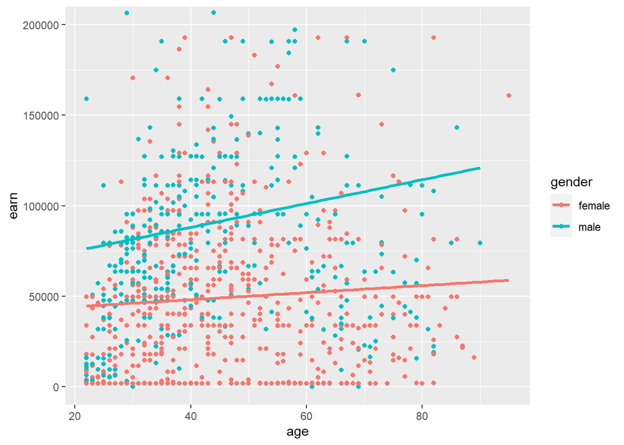

```r
ggplot(aes(x=age,y=earn),data=train)+
  geom_point(aes(color=gender))+
  geom_smooth(aes(color=gender),method="lm",size=1.1,se=F)+
  coord_cartesian(ylim = c(1,200000))
```

So, age is positively related to earn BUT only for males!

# Model 8, Linear Regression to Examine a Non-Linear Relationship: earn = f(age, age^2)

## Estimate

Polynomial Regression

```r
model8 = lm(earn~poly(age,2),data=train)
```

## Predict

How does this R2 compare to that for just model1

```r
summary(model8)
```

```
##
## Call:
## lm(formula = earn ~ poly(age, 2), data = train)
##
## Residuals:
##    Min     1Q Median     3Q    Max
## -77972 -37869  -8752  23077 476591
##
## Coefficients:
##               Estimate Std. Error t value Pr(>|t|)
## (Intercept)      64814       1859  34.858  < 2e-16 ***
## poly(age, 2)1   139869      57850   2.418   0.0158 *
## poly(age, 2)2  -405551      57850  -7.010 4.46e-12 ***
## ---
## Signif. codes:  0 '***' 0.001 '**' 0.01 '*' 0.05 '.' 0.1 ' ' 1
##
## Residual standard error: 57850 on 965 degrees of freedom
## Multiple R-squared:  0.05391,    Adjusted R-squared:  0.05195
## F-statistic:  27.5 on 2 and 965 DF,  p-value: 2.436e-12
```

```r
pred = predict(model8)
sse8 = sum((pred - train$earn)^2)
sst8 = sum((mean(train$earn)-train$earn)^2)
model8_r2 = 1 - sse8/sst8; model8_r2
```

```
## [1] 0.05391354
```

```r
rmse8 = sqrt(mean((pred-train$earn)^2)); rmse8
```

```
## [1] 57760.27
```

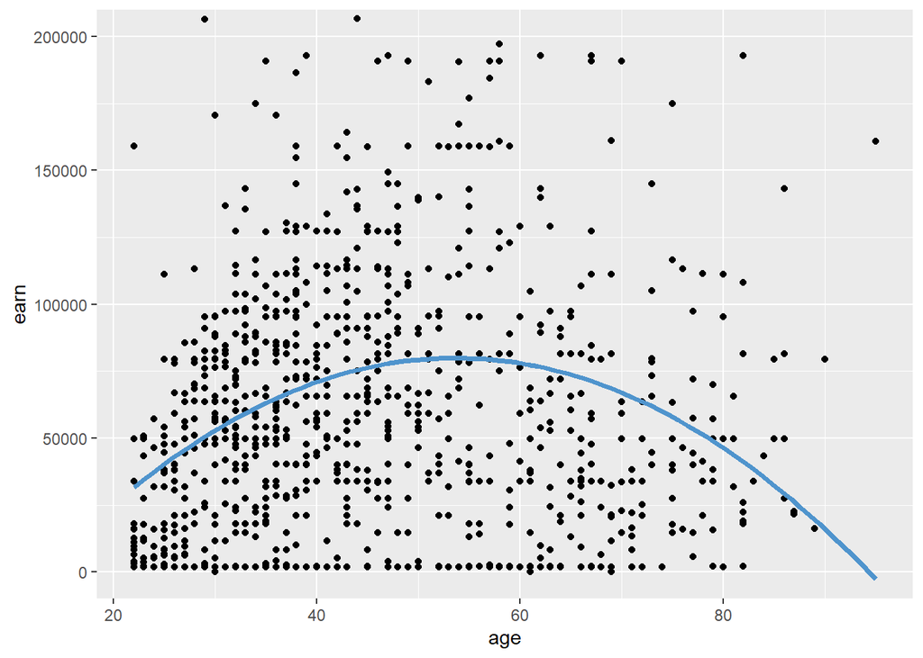

```r
ggplot(aes(x=age,y=earn),data=train)+
  geom_point()+
  geom_smooth(method="lm", formula=y~poly(x,2),size=1.3,se=FALSE, color='steelblue3')+
  coord_cartesian(ylim = c(1,200000))
```

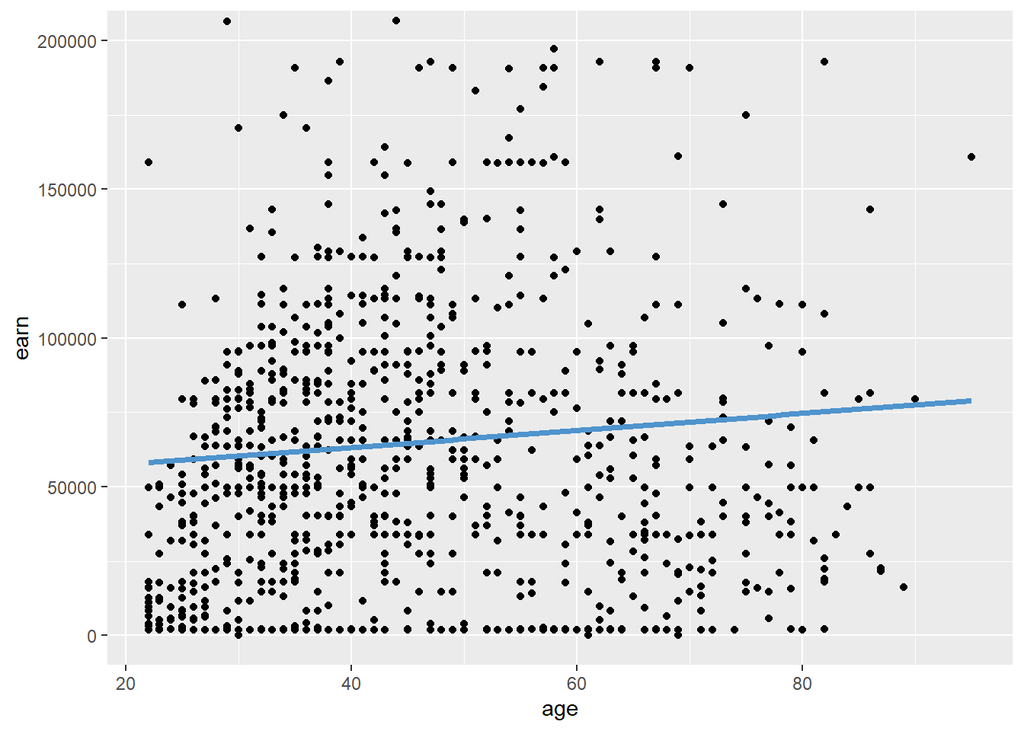

```r
ggplot(data=train,aes(x=age,y=earn))+
  geom_point()+
  geom_smooth(method='lm',size=1.3,color='steelblue3', se=FALSE)+
  coord_cartesian(ylim=c(0,200000))
```

# Model 9, Multiple Regression: earn = f(height, gender, race, ed, age)

## Estimate

```r
model9 = lm(earn~height+gender+race+ed+age,data=train)
```

## Predict

Here we examine the quality of predictions on the sample used to estimate the model.

```r
summary(model9)
```

```
##
## Call:
## lm(formula = earn ~ height + gender + race + ed + age, data = train)
##
## Residuals:
##     Min      1Q  Median      3Q     Max
## -121149  -32051   -6159   21260  438674
##
## Coefficients:
##               Estimate Std. Error t value Pr(>|t|)
## (Intercept)  -204809.1    42188.0  -4.855 1.41e-06 ***
## height          1777.8      632.9   2.809  0.00507 **
## gendermale     30313.4     4790.2   6.328 3.80e-10 ***
## raceasian      17176.3    13660.9   1.257  0.20894
## racehispanic   -4240.7     8962.7  -0.473  0.63621
## racewhite       5900.6     5760.6   1.024  0.30595
## ed              8173.6      674.7  12.114  < 2e-16 ***
## age              562.6      107.2   5.248 1.90e-07 ***
## ---
## Signif. codes:  0 '***' 0.001 '**' 0.01 '*' 0.05 '.' 0.1 ' ' 1
##
## Residual standard error: 51400 on 960 degrees of freedom
## Multiple R-squared:  0.257,  Adjusted R-squared:  0.2516
## F-statistic: 47.44 on 7 and 960 DF,  p-value: < 2.2e-16
```

```r
pred = predict(model9)
sse9 = sum((pred - train$earn)^2)
sst9 = sum((mean(train$earn)-train$earn)^2)
model9_r2 = 1 - sse9/sst9; model9_r2
```

```
## [1] 0.2570262
```

```r
rmse9 = sqrt(mean((pred-train$earn)^2)); rmse9
```

```
## [1] 51185.93
```

## Predict: Out-of-sample

Here we examine the quality of predictions on a sample not used to estimate the model.

```r
pred = predict(model9, newdata=test)
sse9_test = sum((pred - test$earn)^2)
sst9_test = sum((mean(train$earn)-test$earn)^2)
model9_r2_test = 1 - sse9_test/sst9_test; model9_r2_test
```

```
## [1] 0.2317682
```

```r
rmse9_test = sqrt(mean((pred-test$earn)^2)); rmse9_test
```

```
## [1] 60810.34
```

# Comparing Models

Gathering results of all the models run.

```r
model = c('model1', 'model2', 'model3', 'model4', 'model5', 'model6', 'model7', 'model8', 'model9')
sse = c(sse1, sse2, sse3, sse4, sse5, sse6, sse7, sse8, sse9)
rmse = c(rmse1, rmse2, rmse3, rmse4, rmse5, rmse6, rmse7, rmse8, rmse9)
r2 = round(c(model1_r2, model2_r2, model3_r2, model4_r2, model5_r2, model6_r2, model7_r2, model8_r2, model9_r2),4)
results = data.frame(model, sse, rmse, r2)

library(tidyr); library(dplyr)
results
```

| model | sse | rmse | r2 |
| --- | --- | --- | --- |
| model1 | 3.393961e+12 | 59212.82 | 0.0057 |
| model2 | 3.083094e+12 | 56435.93 | 0.0968 |
| model3 | 3.023427e+12 | 55887.16 | 0.1143 |
| model4 | 3.389198e+12 | 59171.26 | 0.0071 |
| model5 | 2.985627e+12 | 55536.70 | 0.1254 |
| model6 | 2.536159e+12 | 51185.93 | 0.2570 |
| model7 | 2.978846e+12 | 55473.60 | 0.1273 |
| model8 | 3.229489e+12 | 57760.27 | 0.0539 |
| model9 | 2.536159e+12 | 51185.93 | 0.2570 |

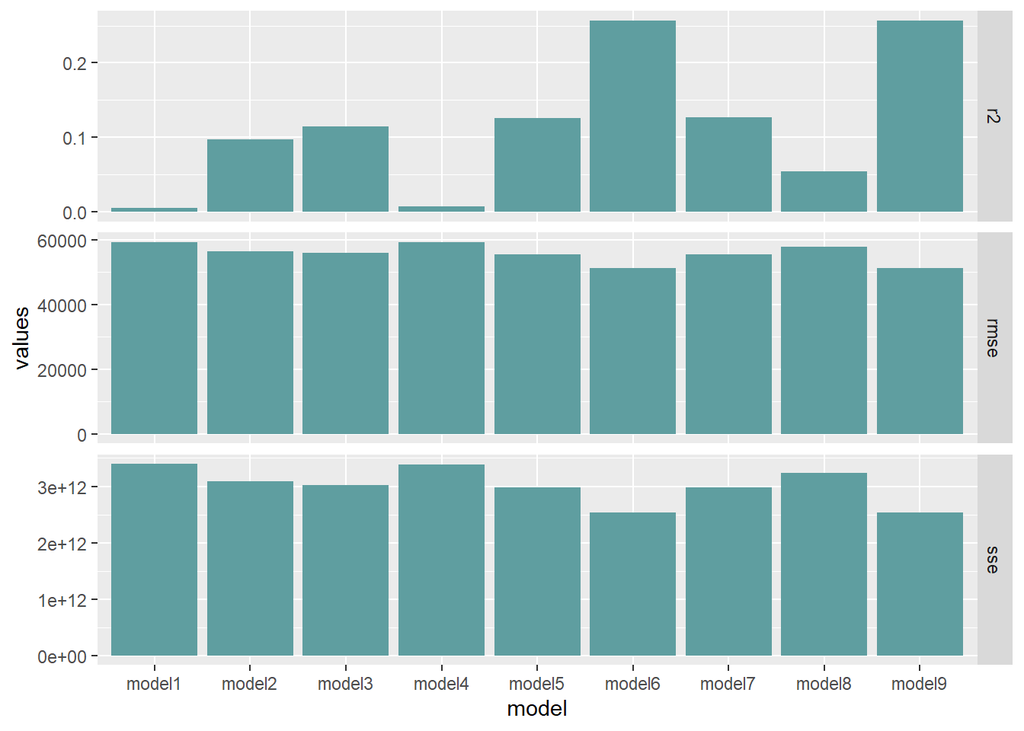

```r
results%>%
  gather(key = metric, value = values,2:4)%>%
  ggplot(aes(x=model, y=values))+
  geom_bar(stat='identity', fill='cadetblue')+
  facet_grid(metric~., scales = 'free_y')
```